# コード例

吉田英嗣

応用社会科学 RA ブートキャンプ応募

```r
#パッケージの読み込み
library(tidyverse)
library(readxl)
library(haven)
```

```r
#データの生成
x <- c(0, 1, 2, 3, 4)
y <- c(3, 5, 7, 19, 44)
```

```r
#データフレームの作成
data <- tibble(x,y)
data
```

```
## # A tibble: 5 × 2
##       x     y
##   <dbl> <dbl>
## 1     0     3
## 2     1     5
## 3     2     7
## 4     3    19
## 5     4    44
```

```r
#データフレームに新たなデータを追加
data$z <- c(2, 4, 7, 5, 8)
data
```

```
## # A tibble: 5 × 3
##       x     y     z
##   <dbl> <dbl> <dbl>
## 1     0     3     2
## 2     1     5     4
## 3     2     7     7
## 4     3    19     5
## 5     4    44     8
```

```r
#データの概観
library(summarytools)
summary(data)
```

```
##        x           y              z
##  Min.   :0   Min.   : 3.0   Min.   :2.0
##  1st Qu.:1   1st Qu.: 5.0   1st Qu.:4.0
##  Median :2   Median : 7.0   Median :5.0
##  Mean   :2   Mean   :15.6   Mean   :5.2
##  3rd Qu.:3   3rd Qu.:19.0   3rd Qu.:7.0
##  Max.   :4   Max.   :44.0   Max.   :8.0
```

データの最小値、第一四分位数、中央値、平均値、第三四分位数、最大値を上から順に並べて、左から、x、y、zと並べた表が表示される

```r
#棒グラフの生成
library(gapminder)
library(gghighlight)
library(ggrepel)
library(stargazer)
```

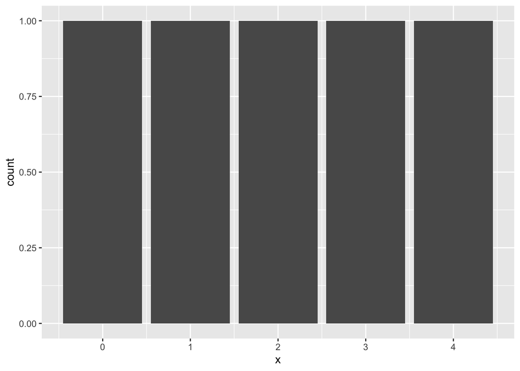

```r
ggplot()+
  geom_bar(aes(x = x), data = data)
```

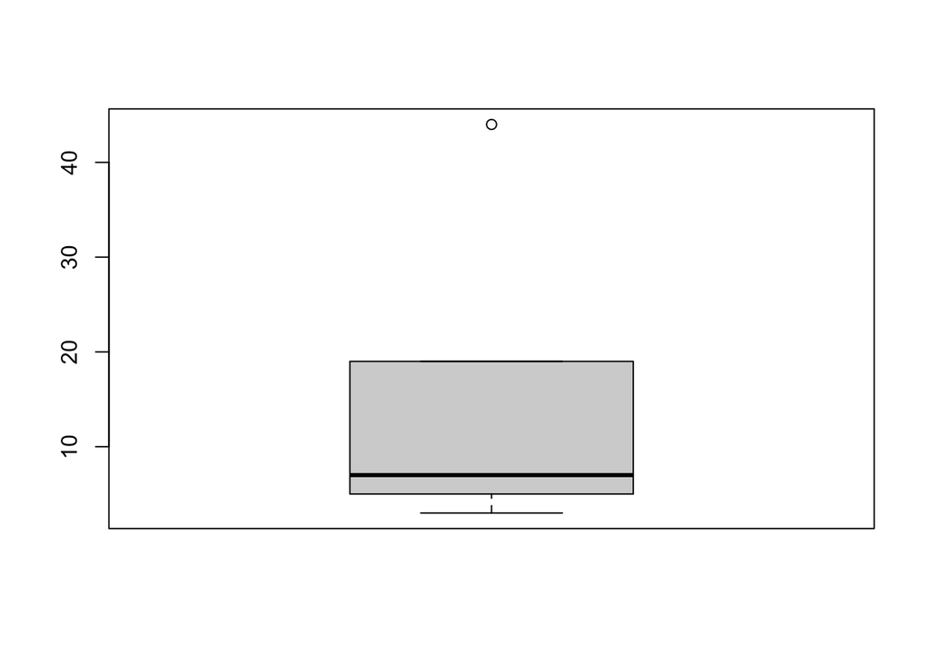

```r
#箱ひげ図の生成
boxplot(y)
```

```r
#データの分散
var(x)
```

```
## [1] 2.5
```

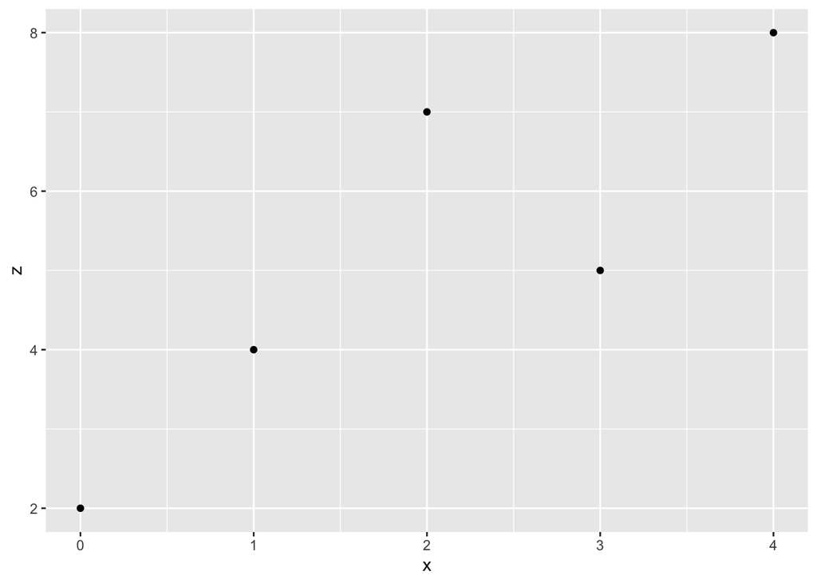

```r
#散布図の生成
ggplot()+
  geom_point(aes(x = x,y = z), data = data)
```

```r
#データの共分散
cov(data$x,data$z)
```

```
## [1] 3.25
```

```r
#相関係数
cor(data$x,data$z)
```

```
## [1] 0.860946
```

```r
#単回帰モデル
model_simple <- lm(x ~ y, data = data)
```

```r
#回帰係数
#切片 #傾き
model_simple$coef
```

```
## (Intercept)           y
##  0.71251719  0.08253095
```

```r
#残差の計算
residuals <- resid(model_simple)
#残差2乗和
sum(residuals^2)
```

```
## [1] 2.077029
```

```r
#回帰式の概要
summary(model_simple, type = "html")
```

```
##
## Call:
## lm(formula = x ~ y, data = data)
##
## Residuals:
##       1       2       3       4       5
## -0.9601 -0.1252  0.7098  0.7194 -0.3439
##
## Coefficients:
##             Estimate Std. Error t value Pr(>|t|)
## (Intercept)  0.71252    0.53228   1.339    0.273
## y            0.08253    0.02440   3.383    0.043 *
## ---
## Signif. codes:  0 '***' 0.001 '**' 0.01 '*' 0.05 '.' 0.1 ' ' 1
##
## Residual standard error: 0.8321 on 3 degrees of freedom
## Multiple R-squared:  0.7923, Adjusted R-squared:  0.7231
## F-statistic: 11.44 on 1 and 3 DF,  p-value: 0.043
```

Call:どの回帰式について掲示しているか

Residuals：それぞれの要素における残差

Coefficients：切片と傾きの回帰係数のEstimateは推定値、Std. Errorは標準誤差、t value はt値、Pr(>|t|)はそれに対応するp値をそれぞれ表している。yのp値は0.05を下回っていることがわかるため、5％で有意であることを示す*が横についている。

```r
#重回帰モデル
model_multiple <- lm(x ~ y + z, data = data)
```

```r
#回帰係数
#切片　#傾き
model_multiple$coef
```

```
## (Intercept)           y           z
## -0.39475794  0.05208141  0.30428615
```

```r
#残差2乗和
residuals <- resid(model_multiple)
sum(residuals^2)
```

```
## [1] 1.044465
```

```r
#回帰式の概要
stargazer(model_multiple, type = "html")
```

|  | *Dependent variable:* |
| --- | --- |
|  | x |
| y | 0.052 |
|  | (0.030) |
| z | 0.304 |
|  | (0.216) |
| Constant | -0.395 |
|  | (0.913) |
| Observations | 5 |
| R<sup>2</sup> | 0.896 |
| Adjusted R<sup>2</sup> | 0.791 |
| Residual Std. Error | 0.723 (df = 2) |
| F Statistic | 8.574 (df = 2; 2) |
| *Note:* | p<0.1; p<0.05; p<0.01 |

y,z,Constantは傾きと切片の回帰係数とその標準誤差、Observationsは観測数、$R^2$ は決定係数、Adjusted $R^2$ は自由度調整をした決定係数、Residual Std. Errorは残差の標準誤差でdfは自由度を表している。また、F Statisticは複合仮設検定のF値でこれもまたdfが自由度を表している。

```r
#データの読み込み（Rデータ）
load("motel.rdata")
```

```r
#データの変数
names(motel)
```

```
## [1] "time"       "days"       "motel_rate" "comp_rate"  "motel_pct"
## [6] "comp_pct"   "repair"     "relprice"
```

```r
#データの概要
summary(motel)
```

```
##       time         days         motel_rate      comp_rate       motel_pct
##  Min.   : 1   Min.   :28.00   Min.   :53.16   Min.   :67.45   Min.   :39.20
##  1st Qu.: 7   1st Qu.:30.00   1st Qu.:54.81   1st Qu.:72.05   1st Qu.:66.70
##  Median :13   Median :31.00   Median :56.13   Median :77.66   Median :77.10
##  Mean   :13   Mean   :30.48   Mean   :56.47   Mean   :76.00   Mean   :75.64
##  3rd Qu.:19   3rd Qu.:31.00   3rd Qu.:58.50   3rd Qu.:78.31   3rd Qu.:84.90
##  Max.   :25   Max.   :31.00   Max.   :60.15   Max.   :83.70   Max.   :96.20
##     comp_pct         repair        relprice
##  Min.   :42.90   Min.   :0.00   Min.   :0.6619
##  1st Qu.:54.80   1st Qu.:0.00   1st Qu.:0.7157
##  Median :61.30   Median :0.00   Median :0.7484
##  Mean   :62.74   Mean   :0.28   Mean   :0.7453
##  3rd Qu.:72.90   3rd Qu.:1.00   3rd Qu.:0.7736
##  Max.   :83.90   Max.   :1.00   Max.   :0.8452
```

```r
#データの先頭(6行)
head(motel)
```

```
##   time days motel_rate comp_rate motel_pct comp_pct repair relprice
## 1    1   31      54.81     71.63      66.7     57.1      0 0.765182
## 2    2   30      53.59     74.21      95.6     54.8      0 0.722140
## 3    3   31      53.37     74.57      95.8     61.3      0 0.715703
## 4    4   30      53.83     77.66      96.2     76.9      0 0.693150
## 5    5   31      56.83     83.70      94.5     78.4      0 0.678973
## 6    6   31      58.50     81.32      89.2     81.4      0 0.719380
```

```r
#データの末尾(6行)
tail(motel)
```

```
##    time days motel_rate comp_rate motel_pct comp_pct repair relprice
## 20   20   31      53.16     78.62      80.4     65.6      1 0.676164
## 21   21   30      57.05     78.31      64.7     53.5      1 0.728515
## 22   22   31      59.69     77.71      45.2     42.9      1 0.768112
## 23   23   31      60.01     78.23      39.2     48.2      1 0.767097
## 24   24   28      58.34     77.95      63.7     54.6      0 0.748428
## 25   25   31      60.15     78.05      74.3     61.3      0 0.770660
```

```r
#データから列を削除する
##repairを削除
motel <- subset(motel, select = -c(repair))
head(motel)
```

```
##   time days motel_rate comp_rate motel_pct comp_pct relprice
## 1    1   31      54.81     71.63      66.7     57.1 0.765182
## 2    2   30      53.59     74.21      95.6     54.8 0.722140
## 3    3   31      53.37     74.57      95.8     61.3 0.715703
## 4    4   30      53.83     77.66      96.2     76.9 0.693150
## 5    5   31      56.83     83.70      94.5     78.4 0.678973
## 6    6   31      58.50     81.32      89.2     81.4 0.719380
```

```r
#データに再度列を追加する
##repairを復元
load("motel.rdata")
motel$repair <- motel$repair
motel
```

```
##    time days motel_rate comp_rate motel_pct comp_pct repair relprice
## 1     1   31      54.81     71.63      66.7     57.1      0 0.765182
## 2     2   30      53.59     74.21      95.6     54.8      0 0.722140
## 3     3   31      53.37     74.57      95.8     61.3      0 0.715703
## 4     4   30      53.83     77.66      96.2     76.9      0 0.693150
## 5     5   31      56.83     83.70      94.5     78.4      0 0.678973
## 6     6   31      58.50     81.32      89.2     81.4      0 0.719380
## 7     7   30      59.19     70.03      85.2     63.2      0 0.845209
## 8     8   31      58.62     72.73      73.7     67.1      0 0.805995
## 9     9   30      55.74     72.05      66.0     56.9      0 0.773629
## 10   10   31      54.61     67.45      71.8     48.6      0 0.809637
## 11   11   31      54.90     68.57      62.9     50.7      0 0.800642
## 12   12   29      55.44     71.46      68.8     56.2      0 0.775819
## 13   13   31      55.88     70.57      78.8     61.7      0 0.791838
## 14   14   30      56.13     73.50      77.4     62.8      0 0.763673
## 15   15   31      56.13     77.07      82.8     58.9      0 0.728299
## 16   16   30      59.43     83.52      84.9     72.9      0 0.711566
## 17   17   31      55.18     83.36      73.8     75.3      1 0.661948
## 18   18   31      57.66     79.78      82.4     83.9      1 0.722738
## 19   19   30      53.52     77.86      77.1     74.2      1 0.687388
## 20   20   31      53.16     78.62      80.4     65.6      1 0.676164
## 21   21   30      57.05     78.31      64.7     53.5      1 0.728515
## 22   22   31      59.69     77.71      45.2     42.9      1 0.768112
## 23   23   31      60.01     78.23      39.2     48.2      1 0.767097
## 24   24   28      58.34     77.95      63.7     54.6      0 0.748428
## 25   25   31      60.15     78.05      74.3     61.3      0 0.770660
```

```r
#データの並び替え
##relpriceが小さい順に並び替える
motel %>%
  arrange(relprice)
```

```
##    time days motel_rate comp_rate motel_pct comp_pct repair relprice
## 17   17   31      55.18     83.36      73.8     75.3      1 0.661948
## 20   20   31      53.16     78.62      80.4     65.6      1 0.676164
## 5     5   31      56.83     83.70      94.5     78.4      0 0.678973
## 19   19   30      53.52     77.86      77.1     74.2      1 0.687388
## 4     4   30      53.83     77.66      96.2     76.9      0 0.693150
## 16   16   30      59.43     83.52      84.9     72.9      0 0.711566
## 3     3   31      53.37     74.57      95.8     61.3      0 0.715703
## 6     6   31      58.50     81.32      89.2     81.4      0 0.719380
## 2     2   30      53.59     74.21      95.6     54.8      0 0.722140
## 18   18   31      57.66     79.78      82.4     83.9      1 0.722738
## 15   15   31      56.13     77.07      82.8     58.9      0 0.728299
## 21   21   30      57.05     78.31      64.7     53.5      1 0.728515
## 24   24   28      58.34     77.95      63.7     54.6      0 0.748428
## 14   14   30      56.13     73.50      77.4     62.8      0 0.763673
## 1     1   31      54.81     71.63      66.7     57.1      0 0.765182
## 23   23   31      60.01     78.23      39.2     48.2      1 0.767097
## 22   22   31      59.69     77.71      45.2     42.9      1 0.768112
## 25   25   31      60.15     78.05      74.3     61.3      0 0.770660
## 9     9   30      55.74     72.05      66.0     56.9      0 0.773629
## 12   12   29      55.44     71.46      68.8     56.2      0 0.775819
## 13   13   31      55.88     70.57      78.8     61.7      0 0.791838
## 11   11   31      54.90     68.57      62.9     50.7      0 0.800642
## 8     8   31      58.62     72.73      73.7     67.1      0 0.805995
## 10   10   31      54.61     67.45      71.8     48.6      0 0.809637
## 7     7   30      59.19     70.03      85.2     63.2      0 0.845209
```

```r
##motel_rateが大きい順に並び替える
motel %>%
  arrange(desc(motel_rate))
```

```
##    time days motel_rate comp_rate motel_pct comp_pct repair relprice
## 25   25   31      60.15     78.05      74.3     61.3      0 0.770660
## 23   23   31      60.01     78.23      39.2     48.2      1 0.767097
## 22   22   31      59.69     77.71      45.2     42.9      1 0.768112
## 16   16   30      59.43     83.52      84.9     72.9      0 0.711566
## 7     7   30      59.19     70.03      85.2     63.2      0 0.845209
## 8     8   31      58.62     72.73      73.7     67.1      0 0.805995
## 6     6   31      58.50     81.32      89.2     81.4      0 0.719380
## 24   24   28      58.34     77.95      63.7     54.6      0 0.748428
## 18   18   31      57.66     79.78      82.4     83.9      1 0.722738
## 21   21   30      57.05     78.31      64.7     53.5      1 0.728515
## 5     5   31      56.83     83.70      94.5     78.4      0 0.678973
## 14   14   30      56.13     73.50      77.4     62.8      0 0.763673
## 15   15   31      56.13     77.07      82.8     58.9      0 0.728299
## 13   13   31      55.88     70.57      78.8     61.7      0 0.791838
## 9     9   30      55.74     72.05      66.0     56.9      0 0.773629
## 12   12   29      55.44     71.46      68.8     56.2      0 0.775819
## 17   17   31      55.18     83.36      73.8     75.3      1 0.661948
## 11   11   31      54.90     68.57      62.9     50.7      0 0.800642
## 1     1   31      54.81     71.63      66.7     57.1      0 0.765182
## 10   10   31      54.61     67.45      71.8     48.6      0 0.809637
## 4     4   30      53.83     77.66      96.2     76.9      0 0.693150
## 2     2   30      53.59     74.21      95.6     54.8      0 0.722140
## 19   19   30      53.52     77.86      77.1     74.2      1 0.687388
## 3     3   31      53.37     74.57      95.8     61.3      0 0.715703
## 20   20   31      53.16     78.62      80.4     65.6      1 0.676164
```

```r
#変数がある値を満たす行だけ取り出す
##repairが0の行のみ取り出す
maroon <- motel %>% filter(repair == 0)
maroon
```

```
##    time days motel_rate comp_rate motel_pct comp_pct repair relprice
## 1     1   31      54.81     71.63      66.7     57.1      0 0.765182
## 2     2   30      53.59     74.21      95.6     54.8      0 0.722140
## 3     3   31      53.37     74.57      95.8     61.3      0 0.715703
## 4     4   30      53.83     77.66      96.2     76.9      0 0.693150
## 5     5   31      56.83     83.70      94.5     78.4      0 0.678973
## 6     6   31      58.50     81.32      89.2     81.4      0 0.719380
## 7     7   30      59.19     70.03      85.2     63.2      0 0.845209
## 8     8   31      58.62     72.73      73.7     67.1      0 0.805995
## 9     9   30      55.74     72.05      66.0     56.9      0 0.773629
## 10   10   31      54.61     67.45      71.8     48.6      0 0.809637
## 11   11   31      54.90     68.57      62.9     50.7      0 0.800642
## 12   12   29      55.44     71.46      68.8     56.2      0 0.775819
## 13   13   31      55.88     70.57      78.8     61.7      0 0.791838
## 14   14   30      56.13     73.50      77.4     62.8      0 0.763673
## 15   15   31      56.13     77.07      82.8     58.9      0 0.728299
## 16   16   30      59.43     83.52      84.9     72.9      0 0.711566
## 24   24   28      58.34     77.95      63.7     54.6      0 0.748428
## 25   25   31      60.15     78.05      74.3     61.3      0 0.770660
```

```r
##repairが1の行のみ取り出す
repaired <- motel %>% filter(repair == 1)
repaired
```

```
##    time days motel_rate comp_rate motel_pct comp_pct repair relprice
## 17   17   31      55.18     83.36      73.8     75.3      1 0.661948
## 18   18   31      57.66     79.78      82.4     83.9      1 0.722738
## 19   19   30      53.52     77.86      77.1     74.2      1 0.687388
## 20   20   31      53.16     78.62      80.4     65.6      1 0.676164
## 21   21   30      57.05     78.31      64.7     53.5      1 0.728515
## 22   22   31      59.69     77.71      45.2     42.9      1 0.768112
## 23   23   31      60.01     78.23      39.2     48.2      1 0.767097
```

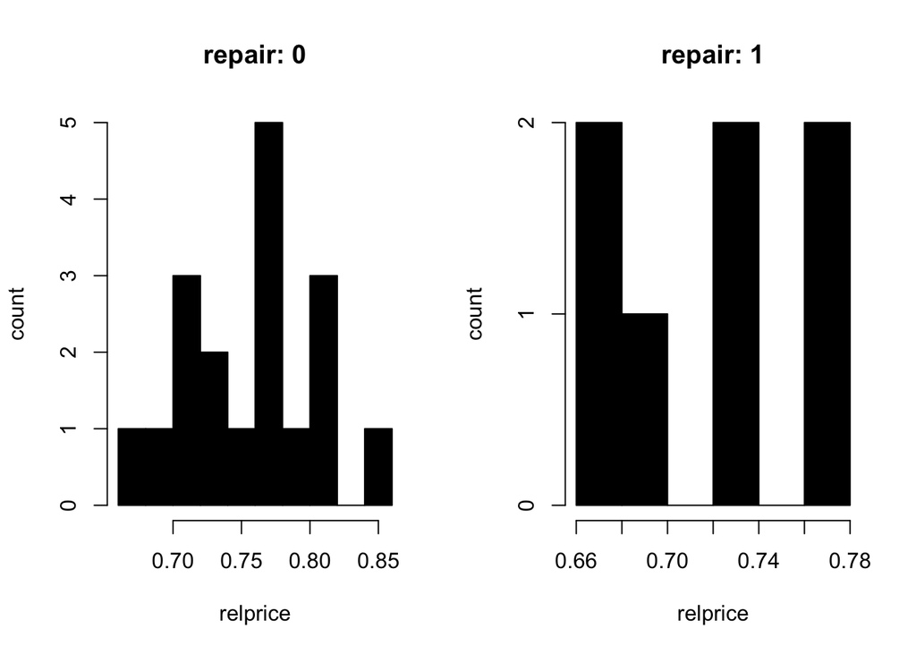

```r
#repairの値で層別化したrelpriceのヒストグラムの生成
repair <- unique(motel$repair)
par(mfrow=c(1, length(repair)))

for (repair in repair){
  hist(motel$relprice[motel$repair == repair],
       main=paste("repair:", repair),
       xlab="relprice",
       ylab="count",
       col="black")
}
```

```r
#relpriceを被説明変数、timeを説明変数とした単回帰分析
reg_time <- lm(relprice ~ time, data = motel)
```

```r
#回帰係数
#切片 #傾き
reg_time$coef
```

```
##   (Intercept)          time
##  0.7515119400 -0.0004797338
```

```r
#残差2乗和
residuals <- resid(reg_time)
sum(residuals^2)
```

```
## [1] 0.05335152
```

```r
#回帰式の概要
stargazer(reg_time, type = "html")
```

|  | *Dependent variable:* |
| --- | --- |
|  | relprice |
| time | -0.0005 |
|  | (0.001) |
| Constant | 0.752*** |
|  | (0.020) |
| Observations | 25 |
| R<sup>2</sup> | 0.006 |
| Adjusted R<sup>2</sup> | -0.038 |
| Residual Std. Error | 0.048 (df = 23) |
| F Statistic | 0.129 (df = 1; 23) |
| *Note:* | p<0.1; p<0.05; p<0.01 |

Observationsは観測数（データの数）、$R^2$は決定係数を表している。

```r
#relpriceを被説明変数、time, days, motel_rate, comp_rate, motel_pct, comp_pct, repairを説明変数とした重回帰分析
reg_multiple <- lm(relprice ~ time + motel_rate + comp_rate + motel_pct + comp_pct + repair, data = motel)
```

```r
#回帰係数
reg_multiple$coef
```

```
##   (Intercept)          time    motel_rate     comp_rate     motel_pct
##  7.542071e-01 -6.716650e-05  1.324598e-02 -1.003028e-02 -2.289751e-05
##      comp_pct        repair
##  1.238681e-04  5.789664e-04
```

```r
#残差2乗和
residuals <- resid(reg_multiple)
sum(residuals^2)
```

```
## [1] 0.0001525654
```

```r
#回帰式の概要
stargazer(reg_multiple, type = "html")
```

|  | *Dependent variable:* |
| --- | --- |
|  | relprice |
| time | -0.0001 |
|  | (0.0001) |
| motel_rate | 0.013*** |
|  | (0.0004) |
| comp_rate | -0.010*** |
|  | (0.0002) |
| motel_pct | -0.00002 |
|  | (0.0001) |
| comp_pct | 0.0001 |
|  | (0.0001) |
| repair | 0.001 |
|  | (0.002) |
| Constant | 0.754*** |
|  | (0.021) |
| Observations | 25 |
| R<sup>2</sup> | 0.997 |
| Adjusted R<sup>2</sup> | 0.996 |
| Residual Std. Error | 0.003 (df = 18) |
| F Statistic | 1,051.972*** (df = 6; 18) |
| *Note:* | p<0.1; p<0.05; p<0.01 |

```r
#データの読み込み（csvデータ）
income <- read.csv("7_1_income.csv")
```

```r
#データの変数
names(income)
```

```
## [1] "female"       "yeduc"        "lincome"      "female_yeduc"
```

```r
#データの先頭(7行)
head(income, 7)
```

```
##   female yeduc  lincome female_yeduc
## 1      0     9 4.605170            0
## 2      0     9 5.010635            0
## 3      0     9 4.605170            0
## 4      0     9 5.010635            0
## 5      0     9 5.329089            0
## 6      0     9 5.329089            0
## 7      0     9 5.521461            0
```

```r
#データの末尾(7行)
tail(income, 7)
```

```
##      female yeduc  lincome female_yeduc
## 4280      1    18 5.521461           18
## 4281      1    18 5.857933           18
## 4282      1    18 6.396930           18
## 4283      1    18 6.396930           18
## 4284      1    18 6.551080           18
## 4285      1    18 6.396930           18
## 4286      1    18 6.620073           18
```

```r
#データの概要
summary(income)
```

```
##      female           yeduc          lincome       female_yeduc
##  Min.   :0.0000   Min.   : 9.00   Min.   :1.833   Min.   : 0.000
##  1st Qu.:0.0000   1st Qu.:12.00   1st Qu.:4.828   1st Qu.: 0.000
##  Median :0.0000   Median :14.00   Median :5.521   Median : 0.000
##  Mean   :0.4984   Mean   :13.86   Mean   :5.261   Mean   : 6.828
##  3rd Qu.:1.0000   3rd Qu.:16.00   3rd Qu.:5.858   3rd Qu.:13.000
##  Max.   :1.0000   Max.   :18.00   Max.   :7.296   Max.   :18.000
```

```r
#データの分散
var(income$lincome)
```

```
## [1] 0.8763454
```

```r
#データの共分散
cov(income$yeduc,income$lincome)
```

```
## [1] 0.2732654
```

```r
#データの相関係数
cor(income$yeduc,income$lincome)
```

```
## [1] 0.1551851
```

```r
#lincomeを被説明変数、yeducを説明変数とした単回帰モデル
model1 <- lm(lincome ~ yeduc, data = income)
```

```r
#回帰係数
#切片　#傾き
model1$coef
```

```
## (Intercept)       yeduc
##   4.1903275   0.0772308
```

```r
#残差2乗和
residuals <- resid(model1)
sum(residuals^2)
```

```
## [1] 3664.707
```

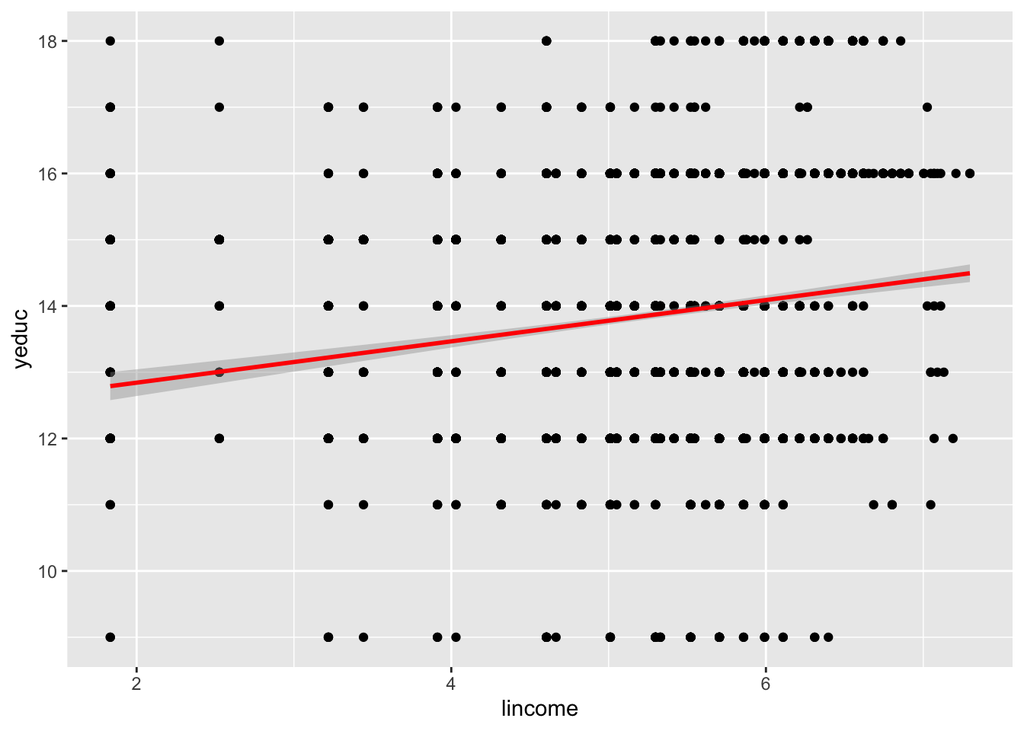

```r
#データの散布図に回帰式を加えたもの
income %>%
  ggplot(aes(x = lincome,y = yeduc))+
    geom_point()+
    geom_smooth(method = "lm", col = "red")
```

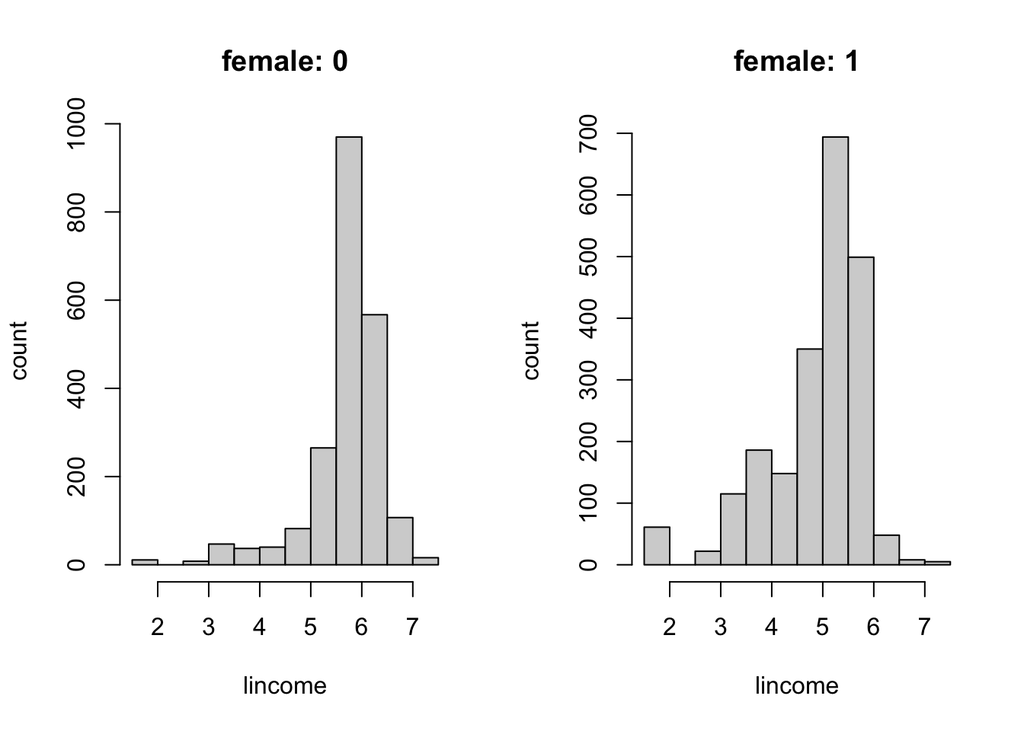

```r
#femaleの値で層別化したlincomeのヒストグラムの生成
sex <- unique(income$female)
par(mfrow=c(1, length(sex)))

for (sex in sex){
  hist(income$lincome[income$female == sex],
       main=paste("female:", sex),
       xlab="lincome",
       ylab="count")
}
```

```r
#被説明変数をlincome、説明変数をfemale, yeduc, female_yeducとした場合の重回帰モデル
model2 <- lm(lincome ~ female + yeduc + female_yeduc, data = income)
```

```r
#回帰係数
#切片　#傾き
model2$coef
```

```
##  (Intercept)       female        yeduc female_yeduc
##   5.34689555  -2.07920201   0.02409467   0.09022853
```

```r
#残差２乗和
residuals <- resid(model2)
sum(residuals^2)
```

```
## [1] 2899.053
```

```r
#回帰式の概要
stargazer(model2, type = "html")
```

|  | *Dependent variable:* |
| --- | --- |
|  | lincome |
| female | -2.079*** |
|  | (0.192) |
| yeduc | 0.024*** |
|  | (0.009) |
| female_yeduc | 0.090*** |
|  | (0.014) |
| Constant | 5.347*** |
|  | (0.121) |
| Observations | 4,286 |
| R<sup>2</sup> | 0.228 |
| Adjusted R<sup>2</sup> | 0.227 |
| Residual Std. Error | 0.823 (df = 4282) |
| F Statistic | 421.490*** (df = 3; 4282) |
| *Note:* | p<0.1; p<0.05; p<0.01 |

```r
#WhiteのSandwich推定量による誤差項の分散不均一の仮定のもとの頑健な標準誤差
library(sandwich)
library(lmtest)
robust_se <- coeftest(model2, vcov = vcovHC(model2, type = "HC1"))
robust_se
```

```
##
## t test of coefficients:
##
##                Estimate Std. Error  t value  Pr(>|t|)
## (Intercept)   5.3468955  0.0888217  60.1980 < 2.2e-16 ***
## female       -2.0792020  0.1862365 -11.1643 < 2.2e-16 ***
## yeduc         0.0240947  0.0067699   3.5591 0.0003762 ***
## female_yeduc  0.0902285  0.0136961   6.5879     5e-11 ***
## ---
## Signif. codes:  0 '***' 0.001 '**' 0.01 '*' 0.05 '.' 0.1 ' ' 1
```

```r
library(remotes)
remotes::install_github("yukiyanai/rgamer")
library(rgamer)
theme_set(theme_gray(base_family ="HiraginoSans-W3"))

packageVersion("rgamer")
```

```
## [1] '0.0.27'
```

```r
#標準形ゲーム
prisoners <- normal_form(
  players = c("囚人1","囚人2"),
  s1 = c("C","D"),
  s2 = c("C","D"),
  payoffs1 = c(-3,0,-10,-5),
  payoffs2 = c(-3,-10,0,-5)
)
```

```r
s_prisoners <- solve_nfg(prisoners,mark_br = FALSE)
```

```
## Pure-strategy NE: [D, D]
```

[output not shown]

```r
#純戦略ナッシュ均衡の表示
s_prisoners$psNE
```

```
## [1] "[D, D]"
```

```r
#利得表
s_prisoners$table
```

|  | strategy | 囚人2 C | 囚人2 D |
| --- | --- | --- | --- |
| 囚人1 | C | -3, -3 | -10, 0 |
|  | D | 0, -10 | -5, -5 |

```r
#利得表に最適反応を示す＾を追加
s_prisoners <- solve_nfg(prisoners,mark_br = TRUE)
```

```
## Pure-strategy NE: [D, D]
```

[output not shown]

```r
s_prisoners$table
```

|  | strategy | 囚人2 C | 囚人2 D |
| --- | --- | --- | --- |
| 囚人1 | C | -3, -3 | -10, 0^ |
|  | D | 0^, -10 | -5^, -5^ |

プレイヤーにとって相手がいかなる戦略を取ろうともDが最適反応であることがわかる。つまりDが両プレイヤーの(強)支配戦略であることがわかる。また、双方の戦略に＾がついている(D,D)がナッシュ均衡であることがわかる。

```r
#混合戦略ナッシュ均衡
g1 <- normal_form(
  players = c("boy","girl"),
  s1 = c("T","B"),
  s2 = c("L","R"),
  payoffs1 = c(3,1,0,1),
  payoffs2 = c(4,0,1,2)
)
```

```r
s_g1 <- solve_nfg(g1, mark_br = FALSE)
```

```
## Pure-strategy NE: [T, L], [B, R]
```

[output not shown]

```r
s_g1$table
```

|  | strategy | girl L | girl R |
| --- | --- | --- | --- |
| boy | T | 3, 4 | 0, 1 |
|  | B | 1, 0 | 1, 2 |

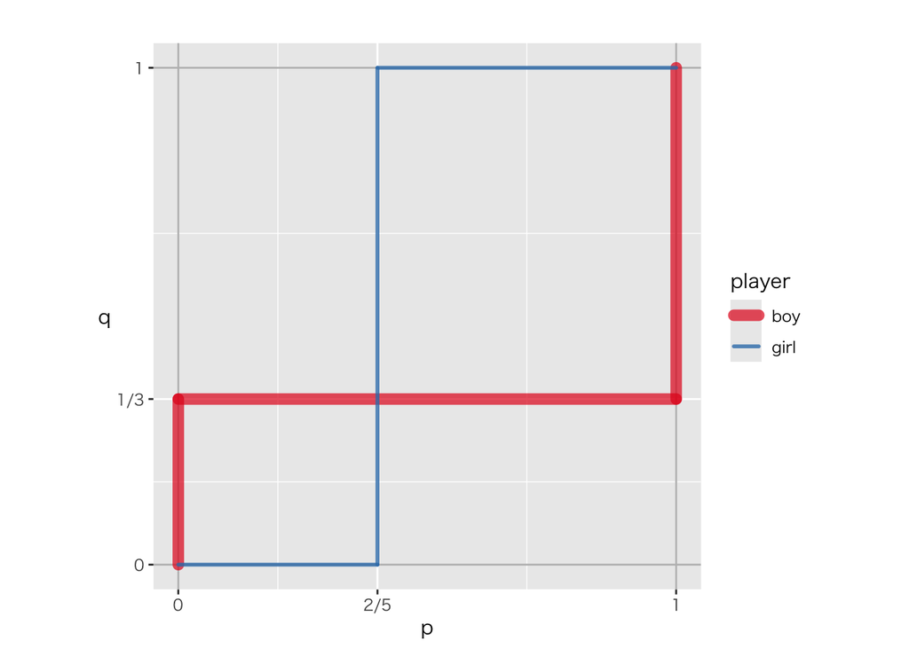

```r
#最適反応曲線
s_g1$br_plot
```

上図より、boyがTをとる確率をp、girlがLをとる確率をqとした場合に混合戦略を含めたナッシュ均衡は(p,q)=(0,0),(2/5,1/3),(1,1)であることがわかる。

```r
#展開型ゲーム
lovers <- extensive_form(
  players = list("p1",
                 c("p2", "p2"),
                 c(NA, NA, NA, NA)),
  actions = list(c("B", "S"),
                 c("B", "S"), c("B", "S")),
  payoffs = list(p1 = c(2,0,0,1),
                 p2 = c(1,0,0,2)),
  direction = "down"
)
```

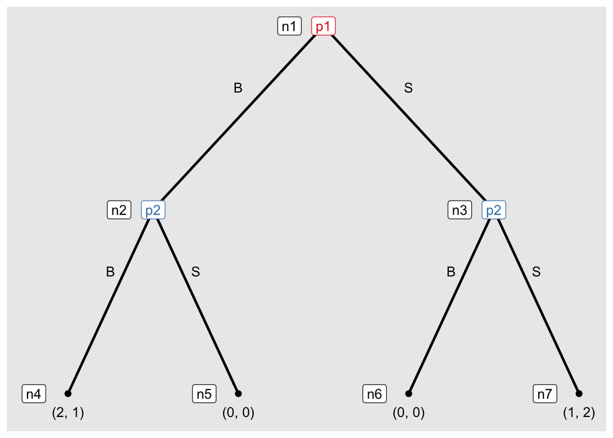

```r
#バックワード・インダクション
s_lovers <- solve_efg(lovers)
```

```
## backward induction: [(B), (B, S)]
```

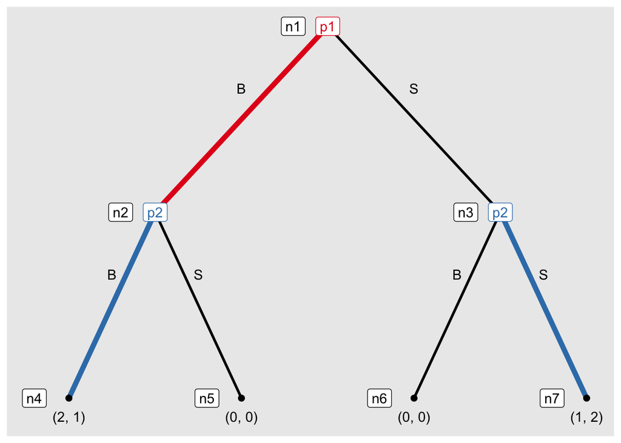

```r
s_lovers$trees[[1]]
```

以上より、このゲームの部分ゲーム完全均衡はp２はp１がBを選んだ場合にB、Sを選んだ場合にSを選び、p１がBを選ぶ戦略の組ということがわかる。

Rを使ってLogit QREを計算することもできる。Logit QREとは相手が思考エラーを起こすものとして、それに対応した最良の確率的な戦略を取るという均衡概念である。

```r
#Logit QREの計算
##関数の読み込み
library(patchwork)
source("solve_qre02.R")
```

```r
#ゲームの利得の定義
payoff1 <- matrix(c(4,0,0,1), nrow = 2, ncol = 2,byrow = FALSE)
payoff2 <- matrix(c(0,1,1,0), nrow = 2, ncol = 2, byrow = FALSE)
payoff1
```

```
##      [,1] [,2]
## [1,]    4    0
## [2,]    0    1
```

```r
payoff2
```

```
##      [,1] [,2]
## [1,]    0    1
## [2,]    1    0
```

```r
#QREの計算
Re <- func_QRE2(
  pi1 = payoff1,
  pi2 = payoff2,
  grid = 0.1,
  M = 10,
  sym = FALSE
)
```

```r
#グラフの表示
func_pic_qre(
  data = Re,
  grid = 0.1,
  M = 10,
  g_title = "Logit QRE"
)
```

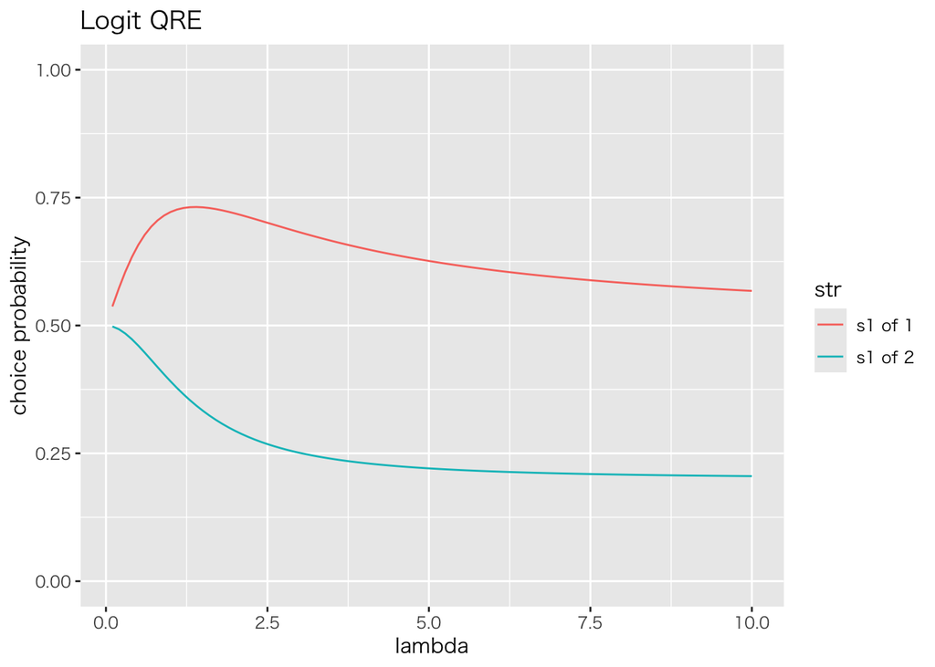

上図のように、ゲームの理解度を表すラムダが大きくなるほど戦略が混合戦略ナッシュ均衡に収束していく。

```r
#EWAのシミュレーション
#ゲームの定義
g <- normal_form(
  players = c("P1", "P2"),
  s1 = c("a", "b"),
  s2 = c("a", "b"),
  payoffs1 = c(1, 0, -2, 1),
  payoffs2 = c(-1, 0, 2, -1)
)
s_g <- solve_nfg(g, mark_br = FALSE)
```

```
## Pure strategy NE does not exist.
```

[output not shown]

```r
s_g$table
```

|  | strategy | P2 a | P2 b |
| --- | --- | --- | --- |
| P1 | a | 1, -1 | -2, 2 |
|  | b | 0, 0 | 1, -1 |

```r
#シミュレーションの定義
set.seed(20240118)

sim_g <- sim_learning(
  game = g,
  n_samples = 1,
  n_periods = 5,
  type = "EWA",
  lambda = 1,
  delta = 0.5,
  rho = 0.5,
  phi = 0.5,
)
```

EWAの魅力度モデル

$A_{i,t+1}(s_i)=\frac{N_t{\phi}A_{i,t}(s_i)+{\delta}*[t期におけるs_iの利得]}{N_{t+1}}$

s.t. $N_{t+1} = {\rho}N_t+1$

に則ってこのように${\delta},{\rho},{\phi}$を仮定してシミュレートする。

```r
#実行結果
sim_g$data
```

```
## # A tibble: 10 × 4
##    sample period player strategy
##     <int>  <int> <chr>  <chr>
##  1      1      1 P1     a
##  2      1      1 P2     a
##  3      1      2 P1     b
##  4      1      2 P2     b
##  5      1      3 P1     a
##  6      1      3 P2     a
##  7      1      4 P1     b
##  8      1      4 P2     a
##  9      1      5 P1     a
## 10      1      5 P2     a
```

この表はそれぞれの機会に各プレイヤーが行った戦略を順番に記している

```r
#魅力度の計算
sim_g$attraction
```

```
## $A1
## $A1[[1]]
##            a          b period
## 1  1.0000000 0.00000000      1
## 2 -0.3333333 0.66666667      2
## 3  0.4285714 0.28571429      3
## 4  0.4666667 0.13333333      4
## 5  0.7419355 0.06451613      5
##
##
## $A2
## $A2[[1]]
##            a           b period
## 1 -1.0000000  1.00000000      1
## 2 -0.3333333 -0.33333333      2
## 3 -0.7142857  0.42857143      3
## 4 -0.3333333 -0.06666667      4
## 5 -0.6774194  0.48387097      5
```

上図はそれぞれのプレイヤーが持つEWAによる魅力度を計算した結果を時期に従って記していったものである。

```r
#確率的な戦略
sim_g$choice_prob
```

```
## $P1
## $P1[[1]]
##           a         b period
## 1 0.5000000 0.5000000      1
## 2 0.7310586 0.2689414      2
## 3 0.2689414 0.7310586      3
## 4 0.5356537 0.4643463      4
## 5 0.5825702 0.4174298      5
##
##
## $P2
## $P2[[1]]
##           a         b period
## 1 0.5000000 0.5000000      1
## 2 0.1192029 0.8807971      2
## 3 0.5000000 0.5000000      3
## 4 0.2417962 0.7582038      4
## 5 0.4337256 0.5662744      5
```

上図はそれぞれのプレイヤーがその期にとる確率的な戦略を記している。

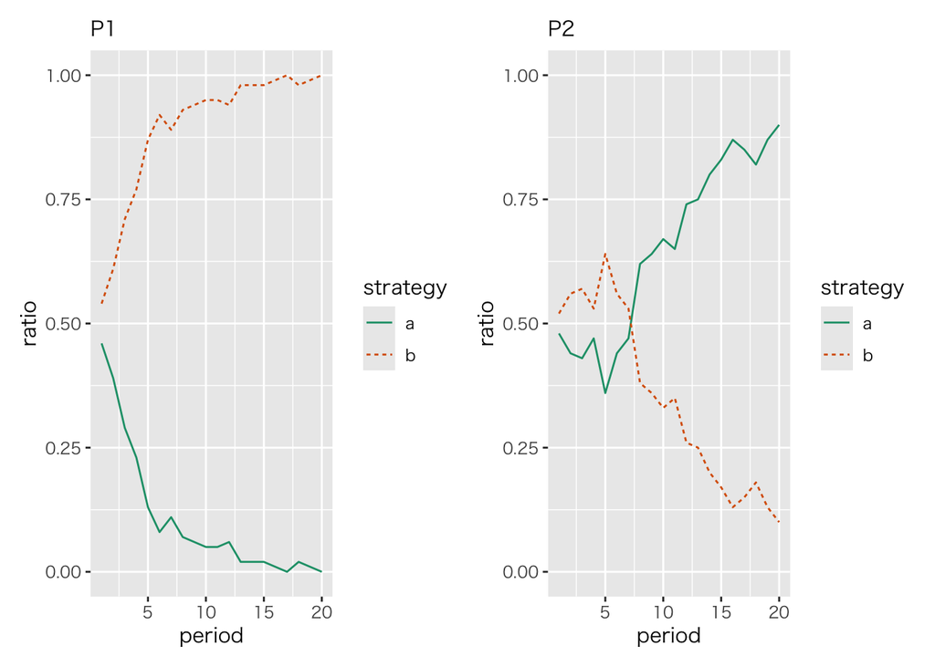

```r
#強化学習
set.seed(20240118)

sim_g2 <- sim_learning(
  game = g,
  n_samples = 100,
  n_periods = 20,
  type = "EWA",
  lambda = 1,
  delta = 0,
  rho = 0,
  phi = 1,
)

sim_g2$plot_mean
```

${\delta}=0,{\phi}=1,{\rho}=0$というEWAの特殊形。強化学習という戦略によって得られた利得がそのまま魅力度に加算されていくLogit型の選択確率の意思決定モデル。

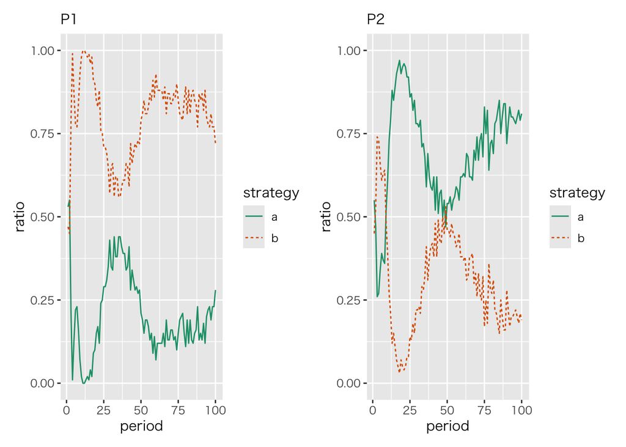

```r
#信念学習（仮想プレイ）
set.seed(20240118)

sim_g3 <- sim_learning(
  game = g,
  n_samples = 100,
  n_periods = 100,
  type = "EWA",
  lambda = 10,
  delta = 1,
  rho = 1,
  phi = 1,
  N_init = 0
)

sim_g3$plot_mean
```

${\delta}=1,{\phi}=1,{\rho}=1,N_1=0$というEWAの特殊形。相手のそれまでとってきた戦略の確率を相手の戦略であると想定した信念学習という意思決定モデル。

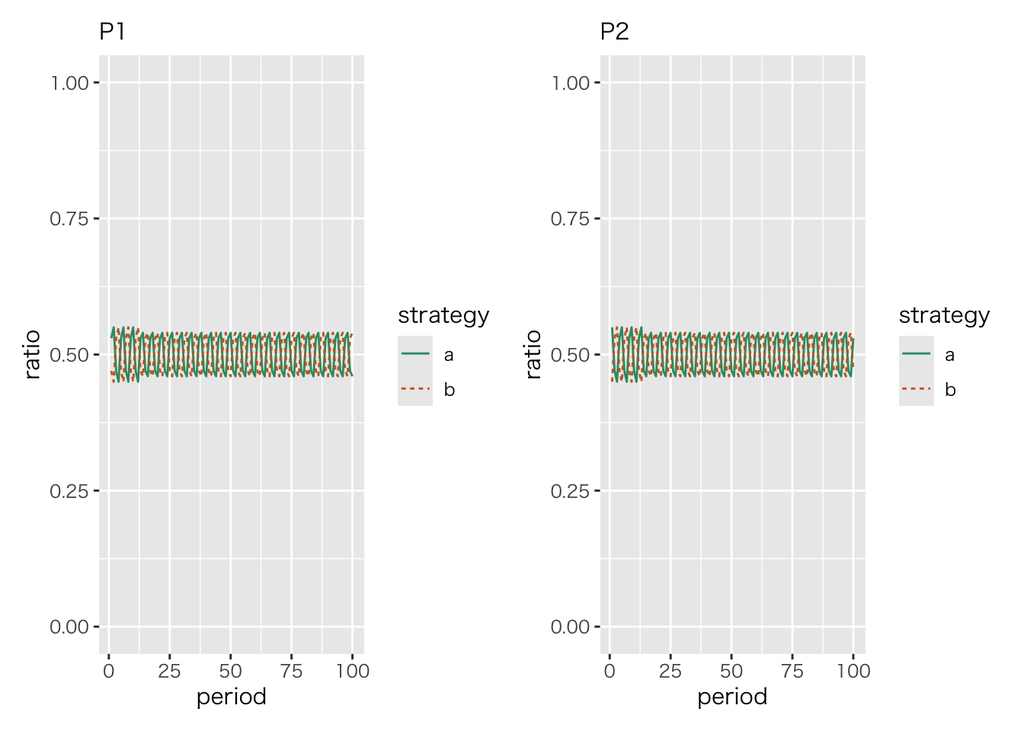

```r
#クールノー動学
set.seed(20240118)

sim_g4 <- sim_learning(
  game = g,
  n_samples = 100,
  n_periods = 100,
  type = "EWA",
  lambda = 10,
  delta = 1,
  rho = 0,
  phi = 0,
  N_init = 0
)

sim_g4$plot_mean
```

${\delta}=1,{\phi}=0,{\rho}=0$というEWAの特殊形。前期の相手の選択に対する最適反応を戦略とする意思決定モデル。